# R Final Project

```r
library(ggplot2)
theme_set(theme_bw())
library(lattice)
library (tidyr)
library(dplyr)
library(ggfortify)
library(readxl)
library(cowplot)
library(randomForest)
library(caret)
library(e1071)
library(rpart)
library(party)
```

### Q1

Upload the excel file “titanic3.xls” using read_excel function from readxl package. Make sure you get the column headers right.

```r
titanic_data <- read_excel('titanic3.xls',col_names=T)
```

```
Coercing text to numeric in M1306 / R1306C13: '328'
```

```r
titanic_data
```

```
# A tibble: 1,309 x 14
   pclass survived name                       sex       age sibsp parch ticket   fare cabin  embarked boat   body home.dest
    <dbl>    <dbl> <chr>                      <chr>   <dbl> <dbl> <dbl> <chr>   <dbl> <chr>  <chr>    <chr> <dbl> <chr>
 1      1        1 Allen, Miss. Elisabeth Wa~ female 29         0     0 24160   211.  B5     S        2        NA St Louis, MO
 2      1        1 Allison, Master. Hudson T~ male    0.917     1     2 113781  152.  C22 C~ S        11       NA Montreal, PQ / Che~
 3      1        0 Allison, Miss. Helen Lora~ female  2         1     2 113781  152.  C22 C~ S        NA       NA Montreal, PQ / Che~
 4      1        0 Allison, Mr. Hudson Joshu~ male   30         1     2 113781  152.  C22 C~ S        NA      135 Montreal, PQ / Che~
 5      1        0 Allison, Mrs. Hudson J C ~ female 25         1     2 113781  152.  C22 C~ S        NA       NA Montreal, PQ / Che~
 6      1        1 Anderson, Mr. Harry        male   48         0     0 19952    26.6 E12    S        3        NA New York, NY
 7      1        1 Andrews, Miss. Kornelia T~ female 63         1     0 13502    78.0 D7     S        10       NA Hudson, NY
 8      1        0 Andrews, Mr. Thomas Jr     male   39         0     0 112050    0   A36    S        NA       NA Belfast, NI
 9      1        1 Appleton, Mrs. Edward Dal~ female 53         2     0 11769    51.5 C101   S        D        NA Bayside, Queens, NY
10      1        0 Artagaveytia, Mr. Ramon    male   71         0     0 PC 176~  49.5 NA     C        NA       22 Montevideo, Uruguay
# ... with 1,299 more rows
```

##### a. Examine the overall chance of survival for a Titanic passenger. Give a number based on the data.

```r
prop.table(table(titanic_data$survived))#The chance of survival for a Titanic passenger is 0.381971
```

```
       0        1
0.618029 0.381971
```

##### b. For each feature make a bar plot / histogram of the fraction of survivors in relation to that feature. For example – one for females vs males, age distribution, etc. On the y-axis you should have “Fraction of survivors”. For the ‘age’ feature, calculate and print also the mean and median age of survivors and the mean and median age of non-survivors.

```r
#selecting the relevant features
df <- titanic_data [,c('pclass','survived','sex','age','sibsp','parch','fare','embarked','cabin','name','body')]
df$survived[is.na(df$survived) & is.na(df$body)] <- 0
df$survived[is.na(df$survived)] <- 1
rownames(df) <- 1:nrow(df)
```

```
Setting row names on a tibble is deprecated.
```

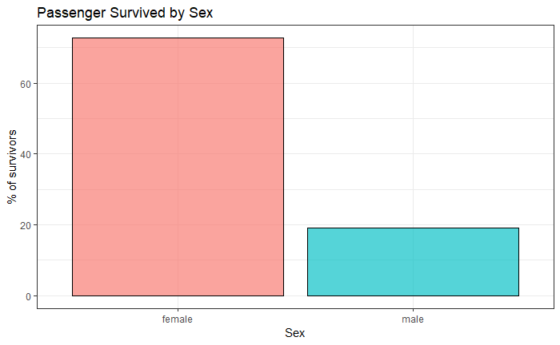

```r
#Sex bar plot
sex_srv <- as.data.frame(prop.table(table(df$sex,df$survived),1))
sex_srv <- filter(sex_srv,Var2==1)
gg_prop1 <- ggplot(data = sex_srv, aes(x = Var1, y = Freq*100, fill = Var1)) +
  geom_bar(stat = 'identity', position = 'dodge', alpha = 2/3, color='black') +
  labs(x = 'Sex', y = '% of survivors', fill = 'Sex', title = 'Passenger Survived by Sex')+
  theme(legend.position = "none")
print(gg_prop1)
```

```r
#We can see that female had bigger chance to survive.
```

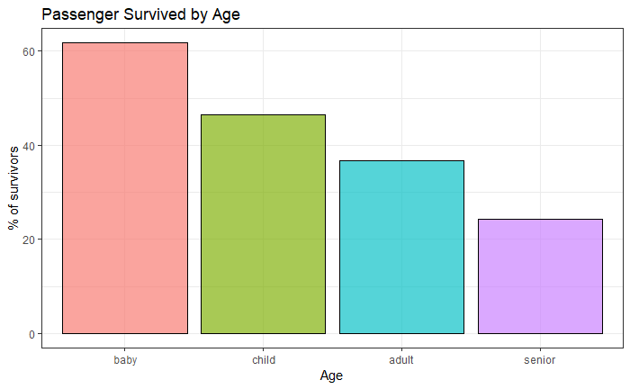

```r
#converting age to categories
df$age[is.na(df$age)] <- mean(df$age, na.rm=TRUE)
df$age_cat <- NA
df$age_cat[df$age <= 2] = " baby"
df$age_cat[df$age > 2 & df$age <= 18] = " child"
df$age_cat[df$age > 18 & df$age <= 60] = "adult"
df$age_cat[df$age > 60] = "senior"
df$age_cat = as.factor(df$age_cat)
#age bar plot
age_srv <- as.data.frame(prop.table(table(df$age_cat,df$survived),1))
age_srv <- filter(age_srv,Var2==1)
gg_prop2 <- ggplot(data = age_srv, aes(x = Var1, y = Freq*100, fill = Var1)) +
  geom_bar(stat = 'identity', position = 'dodge', alpha = 2/3, color='black') +
  theme(legend.position = "none")+
  labs(x = 'Age', y = '% of survivors', fill = 'Age', title = 'Passenger Survived by Age')
print(gg_prop2)
```

```r
age_summary <- summary((filter(df,survived==1))$age)
age_summary <- age_summary
print("mean and median age of survivors:")
```

```
[1] "mean and median age of survivors:"
```

```r
print(age_summary)
```

```
   Min. 1st Qu.  Median    Mean 3rd Qu.    Max.
 0.1667 21.7500 29.8811 29.0588 36.0000 80.0000
```

```r
#Babeis survived more then grounups
```

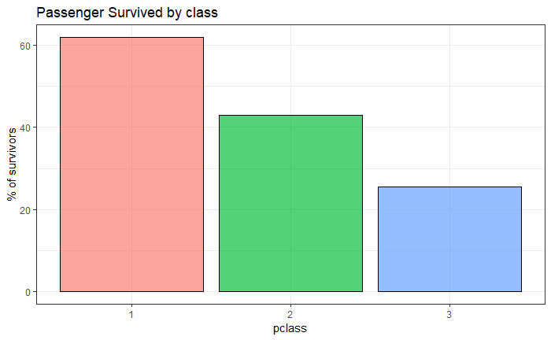

```r
#Class bar plot
pclass_srv <- as.data.frame(prop.table(table(df$pclass,df$survived),1))
pclass_srv <- filter(pclass_srv,Var2==1)
gg_prop3 <- ggplot(data = pclass_srv, aes(x = Var1, y = Freq*100, fill = Var1)) +
  geom_bar(stat = 'identity', position = 'dodge', alpha = 2/3, color='black') +
  theme(legend.position = "none")+
  labs(x = 'pclass', y = '% of survivors', fill = 'Class', title = 'Passenger Survived by class')
print(gg_prop3)
```

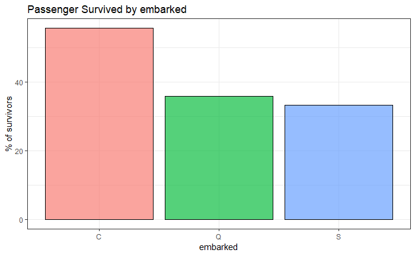

```r
#embarked bar plot
df$embarked[df$embarked == ' '] <- 'S'
embarked_srv <- as.data.frame(prop.table(table(df$embarked,df$survived),1))
embarked_srv <- filter(embarked_srv,Var2==1)
gg_prop4 <- ggplot(data = embarked_srv, aes(x = Var1, y = Freq*100, fill = Var1)) +
  geom_bar(stat = 'identity', position = 'dodge', alpha = 2/3, color='black') +
  theme(legend.position = "none")+
  labs(x = 'embarked', y = '% of survivors', fill = 'Embarked', title = 'Passenger Survived by embarked')
print(gg_prop4)
```

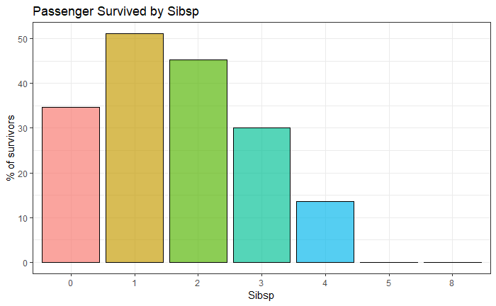

```r
#Sibsp bar plot
df$sibsp[is.na(df$sibsp)] <- 0
sibsp_srv <- as.data.frame(prop.table(table(df$sibsp,df$survived),1))
sibsp_srv <- filter(sibsp_srv,Var2==1)
gg_prop <- ggplot(data = sibsp_srv, aes(x = Var1, y = Freq*100, fill = Var1)) +
  geom_bar(stat = 'identity', position = 'dodge', alpha = 2/3, color='black') +
  theme(legend.position = "none")+
  labs(x = 'Sibsp', y = '% of survivors', fill = 'Sibsp', title = 'Passenger Survived by Sibsp')
print(gg_prop)
```

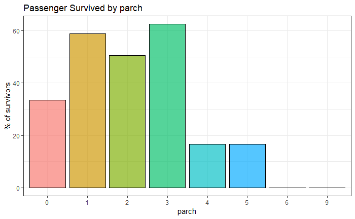

```r
#parch bar plot
df$parch[is.na(df$parch)] <- 0
parch_srv <- as.data.frame(prop.table(table(df$parch,df$survived),1))
parch_srv <- filter(parch_srv,Var2==1)
gg_prop <- ggplot(data = parch_srv, aes(x = Var1, y = Freq*100, fill = Var1)) +
  geom_bar(stat = 'identity', position = 'dodge', alpha = 2/3, color='black') +
  theme(legend.position = "none")+
  labs(x = 'parch', y = '% of survivors', fill = 'Parch', title = 'Passenger Survived by parch')
print(gg_prop)
```

```r
#fare bar plot
# Fill in Fare NAs
df$fare[is.na(df$fare)] <- mean(df$fare, na.rm=TRUE)
df$fare_0 <- NA
df$fare_0[df$fare == 0 | is.na(df$fare)] = "0"
df$fare_0[df$fare > 0] = "> 0"
df$fare_0 = as.factor(df$fare_0)
fare_srv <- as.data.frame(prop.table(table(df$fare_0,df$survived),1))
fare_srv <- filter(fare_srv,Var2==1)
gg_prop <- ggplot(data = fare_srv, aes(x = Var1, y = Freq*100, fill = Var1)) +
  geom_histogram(stat = 'identity', position = 'dodge', alpha = 2/3, color='black') +
  theme(legend.position = "none")+
  labs(x = 'Fare', y = '% of survivors', fill = 'Fare', title = 'Passenger Survived by Fare')
```

```
Ignoring unknown parameters: binwidth, bins, pad
```

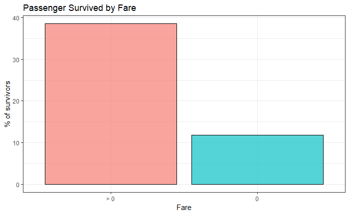

```r
print(gg_prop)
```

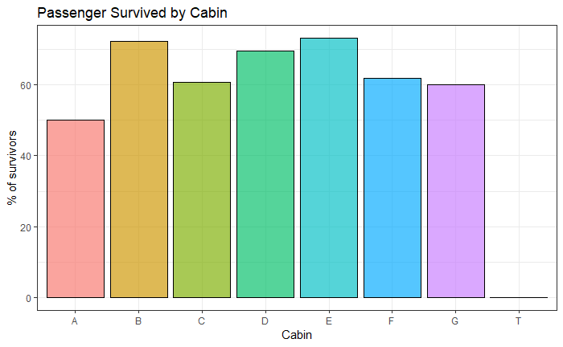

```r
#Cabin bar plot
df$cabin_a <- substr(df$cabin,0,1)
cabin_srv <- as.data.frame(prop.table(table(df$cabin_a,df$survived),1))
cabin_srv <- filter(cabin_srv,Var2==1)
gg_prop <- ggplot(data = cabin_srv, aes(x = Var1, y = Freq*100, fill = Var1)) +
  geom_bar(stat = 'identity', position = 'dodge', alpha = 2/3, color='black') +
  theme(legend.position = "none")+
  labs(x = 'Cabin', y = '% of survivors', fill = 'Cabin', title = 'Passenger Survived by Cabin')
print(gg_prop)
```

[figure not shown]

##### c. Use group_by on the class column (‘pclass’). What are the characteristics of the three classes?

```r
class_carc <- summarise(group_by(df,pclass), mean_age=mean(age))
class_carc$mean_fare <- (summarise(group_by(df, pclass), mean_fare=mean(fare)))$mean_fare
class_carc$passengers <- (tally(group_by(df, pclass)))$n
class_carc$survived <-(summarise(group_by(df, pclass), survived=sum(survived)))$survived
class_carc$f_survived <-(class_carc$survived/class_carc$passengers)*100
class_carc$male <- (tally(group_by(filter(df,sex=="male"),pclass)))$n
class_carc$female <-(tally(group_by(filter(df,sex=="female"),pclass)))$n
class_carc$pclass <- as.character(class_carc$pclass)
class_carc
```

```
# A tibble: 3 x 8
  pclass mean_age mean_fare passengers survived f_survived  male female
  <chr>     <dbl>     <dbl>      <int>    <dbl>      <dbl> <int>  <int>
1 1          38.0      87.5        323      200       61.9   179    144
2 2          29.5      21.2        277      119       43.0   171    106
3 3          26.3      13.3        709      181       25.5   493    216
```

##### d. Create a bar plot indicating the fraction of survivors for each of the three classes separately. Use different colors for different classes. Make the same plot again, this time separating men and women for each one of the three classes (a total of six bars)

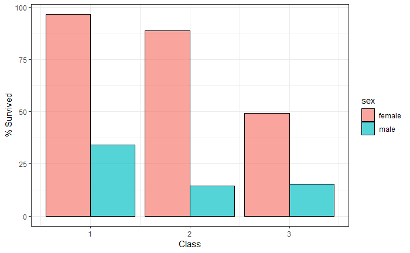

```r
class_m <-  (tally(group_by(filter(df, survived==1 & sex=="male"),pclass)))
class_m$sex <- "male"
class_m$pass <- (tally(group_by(filter(df, sex=="male"),pclass)))$n
class_m$f_srv <- class_m$n/class_m$pass
class_f <-  (tally(group_by(filter(df, survived==1 & sex=="female"),pclass)))
class_f$sex <- "female"
class_f$pass <- (tally(group_by(filter(df, sex=="female"),pclass)))$n
class_f$f_srv <- class_f$n/class_f$pass
class_sex <- bind_rows(class_f,class_m)
ggplot(class_sex,aes(x=pclass,y=f_srv*100,fill=sex))+
  geom_bar(stat="identity" ,position = 'dodge', alpha = 2/3, color='black')+
  xlab("Class")+ylab("% Survived")
```

##### e. Make a plot with 4 subplots of age distributions: males separate from females and survivors separate from non-survivors. What can you conclude based on these plots?

```
Argument 'cols' is deprecated. Use 'ncol' instead.
```

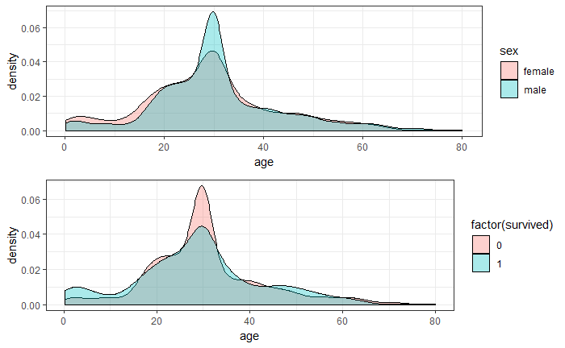

```r
plot1 <- ggplot(df,aes(x=age, fill=sex))+
  geom_density(alpha = 1/3)
plot2 <- ggplot(df,aes(x=age, fill=factor(survived)))+
  geom_density(alpha = 1/3)
plot_grid(plot1, plot2,cols=1)
```

### Q4. Modelling:

#### a. Use PCA on the numerical features, aiming at reducing the data to two dimensions. Plot these first two PCs. Repeat again, this time including ‘sex’ (encoded as numbers), and ‘embarked’ (again, encoded as numbers). Which of the two PCAs seems to be more informative in relation the target? Explain your claim.

```r
#titanic_pca <- na.omit(titanic_data[,c('survived','pclass','age','sibsp','parch','fare','sex','embarked')])
df$sex_n <- 0
df$sex_n [df$sex=="male"] <- 1
df$sex_n [df$sex=="female"] <- 2
df$embarked_n <- 0
df$embarked_n [df$embarked=="C"] <- 1
df$embarked_n [df$embarked=="Q"] <- 2
df$embarked_n [df$embarked=="S"] <- 3
df.pca <- prcomp(df[,c(1,2,4:7)], center = TRUE,scale. = TRUE)
summary(df.pca)
```

```
Importance of components:
                          PC1    PC2    PC3    PC4     PC5     PC6
Standard deviation     1.3771 1.2448 0.9916 0.8027 0.75285 0.59991
Proportion of Variance 0.3161 0.2582 0.1639 0.1074 0.09446 0.05998
Cumulative Proportion  0.3161 0.5743 0.7382 0.8456 0.94002 1.00000
```

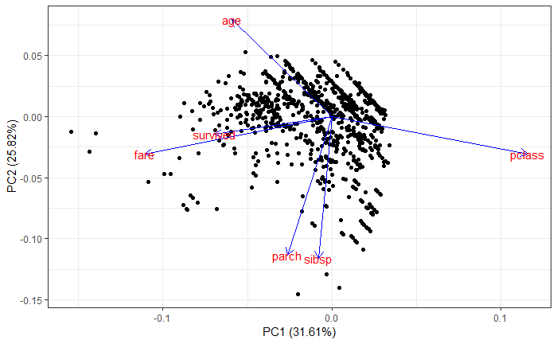

```r
autoplot(df.pca,data=df, loadings = TRUE, loadings.colour = 'blue',
         loadings.label = TRUE, loadings.label.size = 4)
```

```r
df.pca <- prcomp(df[,c(1,2,4:7,15,16)], center = TRUE,scale. = TRUE)
```

```
There were 24 warnings (use warnings() to see them)
```

```r
summary(df.pca)
```

```
Importance of components:
                         PC1    PC2    PC3    PC4     PC5     PC6    PC7     PC8
Standard deviation     1.481 1.2861 1.0956 0.9457 0.82504 0.77698 0.6603 0.58200
Proportion of Variance 0.274 0.2068 0.1500 0.1118 0.08509 0.07546 0.0545 0.04234
Cumulative Proportion  0.274 0.4808 0.6308 0.7426 0.82770 0.90316 0.9577 1.00000
```

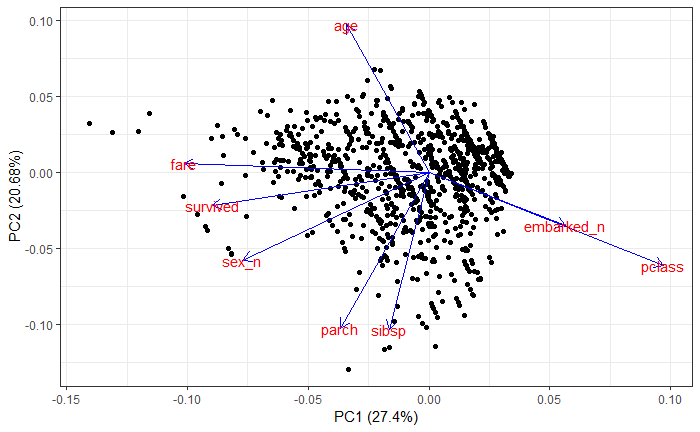

```r
autoplot(df.pca,data=df,  loadings = TRUE, loadings.colour = 'blue',
         loadings.label = TRUE, loadings.label.size = 4)
```

#### b. Partition the data into training and test sets.

```r
# Convert to a string
df$name <- as.character(df$name)
# Engineered variable: Title
df$Title <- sapply(df$name, FUN=function(x) {strsplit(x, split='[,.]')[[1]][2]})
df$Title <- sub(' ', '', df$Title)
# Combine small title groups
df$Title[df$Title %in% c('Mme', 'Mlle')] <- 'Mlle'
df$Title[df$Title %in% c('Capt', 'Don', 'Major', 'Sir')] <- 'Sir'
df$Title[df$Title %in% c('Dona', 'Lady', 'the Countess', 'Jonkheer')] <- 'Lady'
# Convert to a factor
df$Title <- factor(df$Title)
# Engineered variable: Family size
df$FamilySize <- df$sibsp + df$parch + 1
# Engineered variable: Family
df$Surname <- sapply(df$name, FUN=function(x) {strsplit(x, split='[,.]')[[1]][1]})
df$FamilyID <- paste(as.character(df$FamilySize), df$Surname, sep="")
df$FamilyID[df$FamilySize <= 2] <- 'Small'
# Delete erroneous family IDs
famIDs <- data.frame(table(df$FamilyID))
famIDs <- famIDs[famIDs$Freq <= 2,]
df$FamilyID[df$FamilyID %in% famIDs$Var1] <- 'Small'
# Convert to a factor
df$FamilyID <- factor(df$FamilyID)
# New factor for Random Forests, only allowed <32 levels, so reduce number
df$FamilyID2 <- df$FamilyID
# Convert back to string
df$FamilyID2 <- as.character(df$FamilyID2)
df$FamilyID2[df$FamilySize <= 3] <- 'Small'
# And convert back to factor
df$FamilyID2 <- factor(df$FamilyID2)
```

```r
# Split into Train and Test sets
# Training Set : Test Set = 80 : 20 (random)
set.seed(123)
train_v <- sample(nrow(df), 0.8*nrow(df), replace = FALSE)
train <- df[train_v,]
test <- df[-train_v,]
summary(train.df)
```

[output not shown]

```r
summary(test.df)
```

[output not shown]

```r
fit <- randomForest(as.factor(survived) ~ pclass + sex_n + age + sibsp + parch + fare + embarked_n , data=train, importance=TRUE, ntree=2000)
```

```
There were 12 warnings (use warnings() to see them)
```

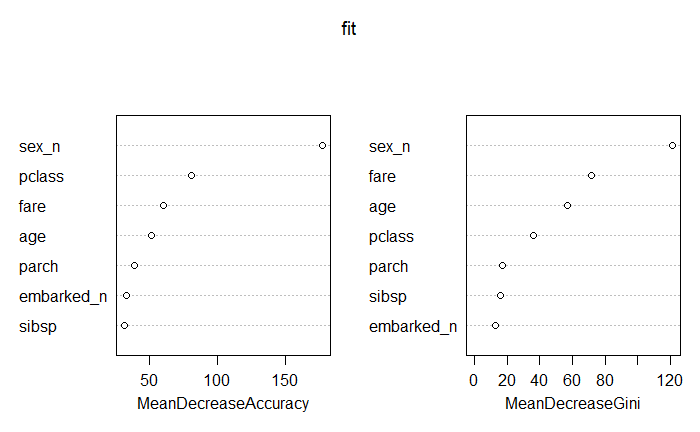

```r
# Look at variable importance
varImpPlot(fit)
```

```r
Prediction_t <- Prediction <- predict(fit, test, OOB=TRUE, type = "response")
confusionMatrix(as.factor(test$survived),as.factor(Prediction_t))
```

```
Confusion Matrix and Statistics

          Reference
Prediction   0   1
         0 153  15
         1  38  56

               Accuracy : 0.7977
                 95% CI : (0.7439, 0.8446)
    No Information Rate : 0.729
    P-Value [Acc > NIR] : 0.006327

                  Kappa : 0.5353
 Mcnemar's Test P-Value : 0.002512

            Sensitivity : 0.8010
            Specificity : 0.7887
         Pos Pred Value : 0.9107
         Neg Pred Value : 0.5957
             Prevalence : 0.7290
         Detection Rate : 0.5840
   Detection Prevalence : 0.6412
      Balanced Accuracy : 0.7949

       'Positive' Class : 0
```

#### d. Try some feature engineering to check if you can improve your predictions - divide ‘age’ into categories, for example. This can help in avoiding overfitting. Similarly, ‘fare’ can be categorized into bins. Suggest some more options for feature engineering, thus creating new or modified features. Test your models again, and see if you’ve managed to improve the accuracy. In addition, check how standardization of ‘age’ and ‘fare’ (without binning) influences models’ accuracy. These continuous features are on different scales so standardization makes sense.

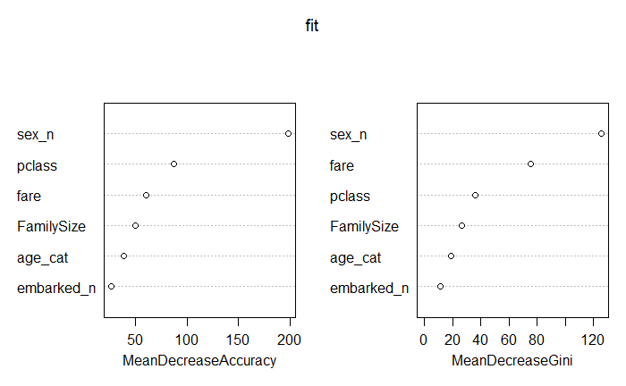

```r
fit <- randomForest(as.factor(survived) ~ pclass + sex_n + age_cat  + fare + embarked_n  + FamilySize , data=train, importance=TRUE, ntree=2000)
# Look at variable importance
varImpPlot(fit)
```

```r
Prediction_t <- Prediction <- predict(fit, test, OOB=TRUE, type = "response")
confusionMatrix(as.factor(test$survived),as.factor(Prediction_t))
```

```
Confusion Matrix and Statistics

          Reference
Prediction   0   1
         0 154  14
         1  38  56

               Accuracy : 0.8015
                 95% CI : (0.748, 0.8481)
    No Information Rate : 0.7328
    P-Value [Acc > NIR] : 0.006100

                  Kappa : 0.5429
 Mcnemar's Test P-Value : 0.001425

            Sensitivity : 0.8021
            Specificity : 0.8000
         Pos Pred Value : 0.9167
         Neg Pred Value : 0.5957
             Prevalence : 0.7328
         Detection Rate : 0.5878
   Detection Prevalence : 0.6412
      Balanced Accuracy : 0.8010

       'Positive' Class : 0
```

#### e. What further information can you get from ‘name’? Look at some names and see if you can identify titles that could be of help. Extract titles and use those as another feature.

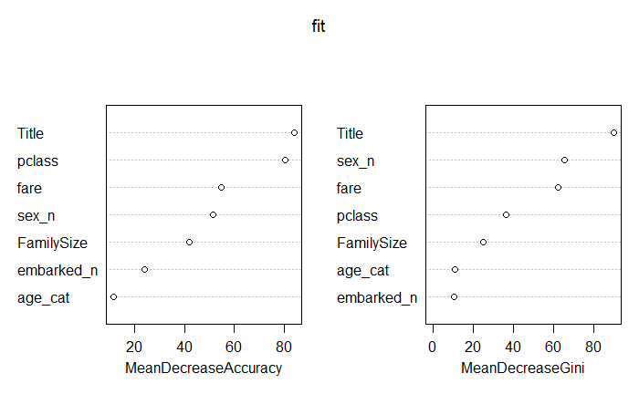

```r
fit <- randomForest(as.factor(survived) ~ pclass + sex_n + age_cat  + fare + embarked_n  + FamilySize + Title , data=train, importance=TRUE, ntree=2000)
# Look at variable importance
VIP <- varImp(fit)
varImpPlot(fit)
```

```r
Prediction_t <- Prediction <- predict(fit, test, OOB=TRUE, type = "response")
confusionMatrix(as.factor(test$survived),as.factor(Prediction_t))
```

```
Confusion Matrix and Statistics

          Reference
Prediction   0   1
         0 149  19
         1  33  61

               Accuracy : 0.8015
                 95% CI : (0.748, 0.8481)
    No Information Rate : 0.6947
    P-Value [Acc > NIR] : 6.46e-05

                  Kappa : 0.554
 Mcnemar's Test P-Value : 0.07142

            Sensitivity : 0.8187
            Specificity : 0.7625
         Pos Pred Value : 0.8869
         Neg Pred Value : 0.6489
             Prevalence : 0.6947
         Detection Rate : 0.5687
   Detection Prevalence : 0.6412
      Balanced Accuracy : 0.7906

       'Positive' Class : 0
```

#### f. The random forest classifier allows one to examine features’ importance. Make a bar plot of features versus their importance according to this classifier.

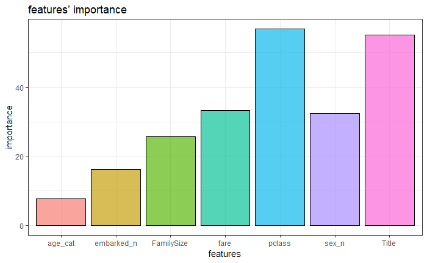

```r
VIP <- varImp(fit)
gg_VIP <- ggplot(data = VIP, aes(x = row.names(VIP), y = VIP$`0`, fill = row.names(VIP))) +
  geom_bar(stat = 'identity', position = 'dodge', alpha = 2/3, color='black') +
  theme(legend.position = "none")+
  labs(x = 'features', y = 'importance', fill = 'Cabin', title = 'features’ importance')
print(gg_VIP)
```